$$ \newcommand{\mat}[1]{\boldsymbol {#1}} \newcommand{\mattr}[1]{\boldsymbol {#1}^\top} \newcommand{\matinv}[1]{\boldsymbol {#1}^{-1}} \newcommand{\vec}[1]{\boldsymbol {#1}} \newcommand{\vectr}[1]{\boldsymbol {#1}^\top} \newcommand{\rvar}[1]{\mathrm {#1}} \newcommand{\rvec}[1]{\boldsymbol{\mathrm{#1}}} \newcommand{\diag}{\mathop{\mathrm {diag}}} \newcommand{\set}[1]{\mathbb {#1}} \newcommand{\norm}[1]{\left\lVert#1\right\rVert} \newcommand{\pderiv}[2]{\frac{\partial #1}{\partial #2}} \newcommand{\bb}[1]{\boldsymbol{#1}} \newcommand{\distas}[1]{\mathbin{\overset{#1}{\kern\z@\sim}}}% $$

# Course Project - Variance Networks

*Jonathan Alush-Aben (309901924) & Shay Avital (049028871)*

## General

This project uses the idea of Variance Layers, as proposed in [Variance Networks: When Expectation Does Not Meet Your Expectations](https://arxiv.org/abs/1803.03764), and extends it to a variation of discrete distributions. We explore various discretized distributions formed from the normal and uniform distributions.

## Summary of the proposal in the article

The Main goal of the article is to study an extreme case of stochastic neural networks where all the weights in one or more layers have a zero mean and trainable variance, e.g. $W_{ij}\sim \mathcal{N}(0, \sigma_{ij}^2)$.

### Key results in the article

#### The article discuss results in 3 main topics:

1. Introduction of "Variance Layers", a new kind of stochastic layers that store information only in the variances of its weights, keeping the means fixed at zero. Objects are mapped into zero-mean distributions over activations. The variance layer is a simple example when the weight scaling rule (Srivastava et al. (2014)) fails.
2. Drawing the connection between neural networks with variance layers (variance networks) and conventional Bayesian deep learning models.
3. Demonstration of how surprisingly well Variance layers perform on a number of deep learning problems.

### STOCHASTIC NEURAL NETWORKS

Relative to the definition of a stochastic neural network being a function that outputs the predictive distribution $p(t | \vec{x}, W)$ of targets t given an object $\vec{x}$ and weights $W$, The researchers consider a special case of stochastic deep neural networks where the parameters $W$ are drawn from a parametric distribution $q(W | \phi)$. During training the parameters $\phi$ are adjusted to the training data $(X, T)$ by minimizing the **sum of the expected negative log-likelihood** and an optional regularization term $R(\phi)$. In practice this objective equation 1 is minimized using one-sample minibatch gradient estimation.

$$−\mathbb{E}_{q(W | \phi)} log\ p(T | X, W) + R(\phi) \rightarrow \displaystyle \mathop{min}_{\phi}\ \ \ \ \ \ \ \ \ \ \ \ \ \ \ \ \ \ \ \ \ \ \ \ \ \ \ \ \ \ \ \ \ \ \ \ \ \ \ \ \ \ \ \ \ \ \ (1)$$

While the exact predictive distribution $\mathbb{E}_{q(W | \phi)}p(t | x, W )$ for such models is usually intractable, it can be approximated using K independent samples of the weights equation 2. This technique is known as **test-time averaging**. Its complexity increases linearly in K.

$$\ p(t | x) = \mathbb{E}_{q(W | \phi)}\ p(t | x, W)\ \stackrel{\sim}{\_} \frac{1}{K}\ \sum\limits_{k=1}^{K}p(t | x, \hat{{W}_{k}}),\ \hat{{W}_k} \sim q(W | \phi)\ \ \ \ \ \ \ \ (2)$$

In order to obtain a more computationally efficient estimation, it is common practice to replace the weights with their expected values equation 3. This approximation is known as the weight scaling rule. $$\ \mathbb{E}_{q(W | \phi)}\ p(t | x, W)\ \stackrel{\sim}{\sim}\ p(t | x, \mathbb{E}_{q}W)\ \ \ \ \ \ \ \ \ \ \ \ \ \ \ \ \ \ \ \ \ \ \ \ \ \ \ \ \ \ \ \ \ \ \ \ \ \ \ \ \ \ \ \ \ \ \ \ \ \ \ \ \ \ \ \ \ (3)$$

while being mathematically incorrect, this rule still performs very well on practice. The success of **weight scaling rule** implies that a lot of learned information is concentrated in the expected value of the weights.

In the paper the researchers consider symmetric weight distributions $$q(W | \phi)\ =\ q(−W | \phi)$$.

Such distributions cannot store any information about the training data in their means as $\mathbb{E}W\ =\ 0$.

## Variance Layer

The article describes the usage of Variance Layer in the form of a singlefully-connected layer. The researchers are commenting that it is done for simplicity and that equivalent results also apply to convolutional and other linear transformations.

### Notations

- $I$ - input neurons.
- $O$ - output neurons.
- $a_{k}\in R^{I}$ - Input vector.
- $b_{k}\in R^{O}$ - Output vector.
- $W \in R^{I\times O}$ - Input vector.
- $b_{k}^{T} = a_{k}^{T}W$ - Output of the layer.
- $\epsilon \sim \mathcal{N}(0, 1)$ - A standard normal distributed random variable.

### Distribution of activations

As deduced by referenced article ( (Wang & Manning (2013)), a Gaussian distribution over the weights implies a Gaussian distribution over the activations. This fact is used in the local reparameterization trick and the researchers also relay on it in their experiments.

$$\displaystyle \mathop{b_{kj} = \sum_{i=1}^{I} \alpha_{ki}\mu_{ij} + \epsilon_{j} · \sqrt{\sum_{i=1}^{I} \alpha_{ki}^{2}\sigma_{ij}^{2}}}_{ Conventional\ layer}\ \ \ \ \ \ \ \ \ \ \ \ \ \ \ \ \ \ \ \ \ \ \ \ \ \ \ \ \ \ \ \ \ \ \ \ \ \ \ \ \ \ \ \ \ \ \ \ \displaystyle \mathop{b_{kj} = \epsilon_{j} · \sqrt{\sum_{i=1}^{I} \alpha_{ki}^{2}\sigma_{ij}^{2}}}_{ Variance\ layer}\ \ \ \ \ \ \ \ \ \ \ \ \ \ \ \ \ \ \ \ \ \ \ \ (4)$$

In Gaussian variance layer an expectation of $b_{mj}$ is exactly zero, so the first term in eq. equation 4 disappears. During training, the layer can only adjust the variances $\sum_{i}^{I} \alpha_{ki}^{2}\sigma_{ij}^{2}$ of the output. It means that each object is encoded by a **zero-centered fully-factorized multidimensional Gaussian** rather than by a single point non-zero-mean Gaussian.

## Summary of our improvement

The focus of our project is analyzing the effects of different discretized distibutions. The discetization is done through a rounding function - defined as **[Random value from continuous dist.*R]/R** where [ ] indicates the nearest whole number. Our Rounded-Variance layers' variance is trained, in a zero mean distribution which takes a discrete set of values as defined by the rounding number **R**.

We will perform 8 experiments, using variantions of LeNet5, with one of the FC/Conv layers changed to a RoundedVarianceFC/Conv layer, testing both discretized uniform and normal distributions. These will be trained and tested on MNIST and CIFAR10.

Its important to state that although LeNet5 is not optimal for the CIFAR10 problem, what we were interested in is the comparison to the results of the Variance net (layers) and not specifically state of the art results.

The base architecture we rely on follows:

```python
experiments.print_architecture('LeNet5','MNIST',0)
```

```
LeNet5(
  (feature_extractor): Sequential(
    (0): Conv2d(1, 20, kernel_size=(3, 3), stride=(1, 1), padding=(1, 1), bias=False)
    (1): BatchNorm2d(20, eps=1e-05, momentum=0.1, affine=False, track_running_stats=True)
    (2): ReLU()
    (3): MaxPool2d(kernel_size=(2, 2), stride=(2, 2), padding=0, dilation=1, ceil_mode=False)
    (4): BatchNorm2d(20, eps=1e-05, momentum=0.1, affine=True, track_running_stats=True)
    (5): ReLU()
    (6): MaxPool2d(kernel_size=(2, 2), stride=(2, 2), padding=0, dilation=1, ceil_mode=False)
  )
  (classifier): Sequential(
    (0): Linear(in_features=980, out_features=500, bias=False)
    (1): BatchNorm1d(500, eps=1e-05, momentum=0.1, affine=False, track_running_stats=True)
    (2): ReLU()
    (3): Linear(in_features=500, out_features=10, bias=False)
  )
)
```

In our experiments, we will change the first Conv2d layer in the feature extractor, or the first Linear Fully Connected layer in the classifier into a variance layer. This means that instead of weight matrix $W = const $, we have: $$ W_{ij} \sim D(0,X_{ij})$$ where $D$ is a discrete distribution $X$ is the variance, which is the layer's parameter and $0$ is the mean. In this project, we are checking examples where $$D = [\mathcal{N}(0,X_{ij})*R]/R $$or$$ D = [U(-X_{ij},X_{ij})*R]/R$$ Notice that the variance is proportional to $X_{ij}$, and thus it's a valid parameter to use for training a variance layer.

```python
import os
import re
import sys
import glob
import numpy as np
import matplotlib.pyplot as plt
import unittest
import torch
import torchvision
import torchvision.transforms as tvtf

%matplotlib inline
%load_ext autoreload
%autoreload 2

seed = 42
device = torch.device('cuda' if torch.cuda.is_available() else 'cpu')

plt.rcParams.update({'font.size': 12})
test = unittest.TestCase()
import core.experiments as experiments
from core.experiments import load_experiment
from utils.plot import plot_fit
```

We'll use the following function to load multiple experiment results and plot them together.

```python
def plot_exp_results(filename_pattern, results_dir='results'):
    fig = None
    result_files = glob.glob(os.path.join(results_dir, filename_pattern))
    result_files.sort()
    if len(result_files) == 0:
        print(f'No results found for pattern {filename_pattern}.', file=sys.stderr)
        return
    for filepath in result_files:
        print(filepath)
        m = re.match('exp\d_(\d_)?(.*)\.json', os.path.basename(filepath))
        cfg, fit_res = load_experiment(filepath)
        fig, axes = plot_fit(fit_res, fig, legend=m[2],log_loss=True)
    del cfg['filters_per_layer']
    del cfg['layers_per_block']
    print('common config: ', cfg)
    experiments.print_architecture(cfg['ycn'],cfg['dataset'],cfg['kw']['rounding'])
```

#### Experiments : Varied LeNet5 Architectures with a Rounded-Variance layers

We'll see the comparison between a normally distributed layer, to discretised normal layers where a layer takes values tuned to 1/R. We expect that as $R \to \infty$ the distributions will go to the original continuous distributions.

**Configurations**:

Below are the results and analysis of the various configuations as described above, with different discrete distributions. Note that Rounding=0 corresponds to a continuous distribution.

**Experiment 1 - MNIST with discretized Normal Distributions Using a Convolutional Variance Layer**

```
results/exp1_MNIST_NORM_CONVVAR_R0.json
results/exp1_MNIST_NORM_CONVVAR_R1.json
results/exp1_MNIST_NORM_CONVVAR_R100.json
results/exp1_MNIST_NORM_CONVVAR_R1000.json
results/exp1_MNIST_NORM_CONVVAR_R2.json
common config:  {'run_name': 'exp1_MNIST_NORM_CONVVAR_R2', 'out_dir': './results', 'seed': 1811189179, 'bs_train': 128, 'bs_test': 32, 'batches': 100, 'epochs': 100, 'early_stopping': 5, 'checkpoints': None, 'lr': 0.0015, 'reg': 0.0002, 'pool_every': 0, 'hidden_dims': 0, 'ycn': 'LeNet5ConvVariance',…
LeNet5ConvVariance(
  (feature_extractor): Sequential(
    (0): ConvVariance(1, 20, kernel_size=(5, 5), stride=1, padding=0, dilation=1, rounding=2, bias=False)
    (1): BatchNorm2d(20, eps=1e-05, momentum=0.1, affine=False, track_running_stats=True)
    (2): ReLU()
    (3): MaxPool2d(kernel_size=(2, 2), stride=(2, 2), padding=0, dilation=1, ceil_mode=False)
    (4): Conv2d(20, 50, kernel_size=(5, 5), stride=(1, 1), bias=False)
    (5): BatchNorm2d(50, eps=1e-05, momentum=0.1, affine=False, track_running_stats=True)
    (6): ReLU()
    (7): MaxPool2d(kernel_size=(2, 2), stride=(2, 2), padding=0, dilation=1, ceil_mode=False)
  )
  (classifier): Sequential(
    (0): Linear(in_features=800, out_features=500, bias=True)
    (1): BatchNorm1d(500, eps=1e-05, momentum=0.1, affine=False, track_running_stats=True)
    (2): ReLU()
    (3): Linear(in_features=500, out_features=10, bias=True)
  )
)
```

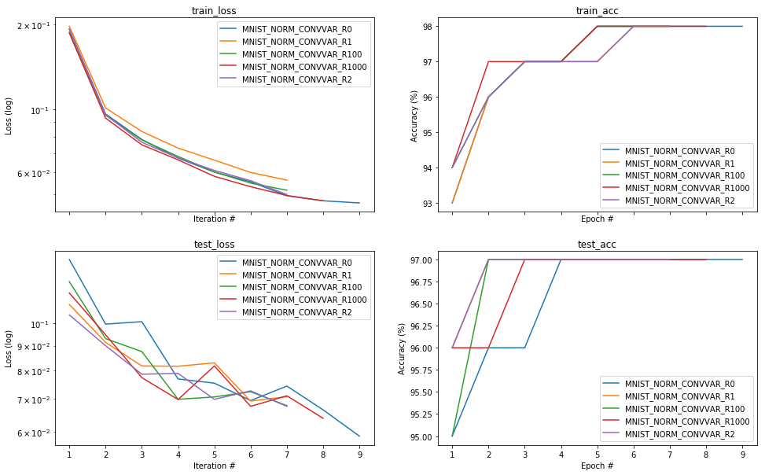

```python
plot_exp_results('exp1*.json')
```

### Results:

| R | Best Train Loss | Best Train acc | Best Test loss | best Test acc |
| --- | --- | --- | --- | --- |
| R0 | 0.04661195497832763 | 98 | 0.05877627432346344 | 97 |
| R1 | 0.056134116607529524 | 98 | 0.07077297568321228 | 97 |
| R2 | 0.04993517612164685 | 98 | 0.06762083619832993 | 97 |
| R100 | 0.051691762531108694 | 98 | 0.0678543895483017 | 97 |
| R1000 | 0.047432279962895396 | 98 | 0.06392242759466171 | 97 |

1. Further questions: Is this layer just a trained dropout+linear layer?
2. mention: R0 is the slowest to train but it is specific only to the Norm distribution with CONVVAR layers.

**Experiment 2 - MNIST with discretized Uniform Distributions Using a Convolutional Variance Layer**

```
results/exp2_MNIST_UNIF_CONVVAR_R0.json
results/exp2_MNIST_UNIF_CONVVAR_R1.json
results/exp2_MNIST_UNIF_CONVVAR_R100.json
results/exp2_MNIST_UNIF_CONVVAR_R1000.json
results/exp2_MNIST_UNIF_CONVVAR_R2.json
common config:  {'run_name': 'exp2_MNIST_UNIF_CONVVAR_R2', 'out_dir': './results', 'seed': 1679268856, 'bs_train': 128, 'bs_test': 32, 'batches': 100, 'epochs': 100, 'early_stopping': 5, 'checkpoints': None, 'lr': 0.0015, 'reg': 0.0002, 'pool_every': 0, 'hidden_dims': 0, 'ycn': 'LeNet5ConvVarianceUn…
LeNet5ConvVarianceUnif(
  (feature_extractor): Sequential(
    (0): ConvVarianceUnif(1, 20, kernel_size=(5, 5), stride=1, padding=0, dilation=1, bias=False)
    (1): BatchNorm2d(20, eps=1e-05, momentum=0.1, affine=False, track_running_stats=True)
    (2): ReLU()
    (3): MaxPool2d(kernel_size=(2, 2), stride=(2, 2), padding=0, dilation=1, ceil_mode=False)
    (4): Conv2d(20, 50, kernel_size=(5, 5), stride=(1, 1), bias=False)
    (5): BatchNorm2d(50, eps=1e-05, momentum=0.1, affine=False, track_running_stats=True)
    (6): ReLU()
    (7): MaxPool2d(kernel_size=(2, 2), stride=(2, 2), padding=0, dilation=1, ceil_mode=False)
  )
  (classifier): Sequential(
    (0): Linear(in_features=800, out_features=500, bias=True)
    (1): BatchNorm1d(500, eps=1e-05, momentum=0.1, affine=False, track_running_stats=True)
    (2): ReLU()
    (3): Linear(in_features=500, out_features=10, bias=True)
  )
)
```

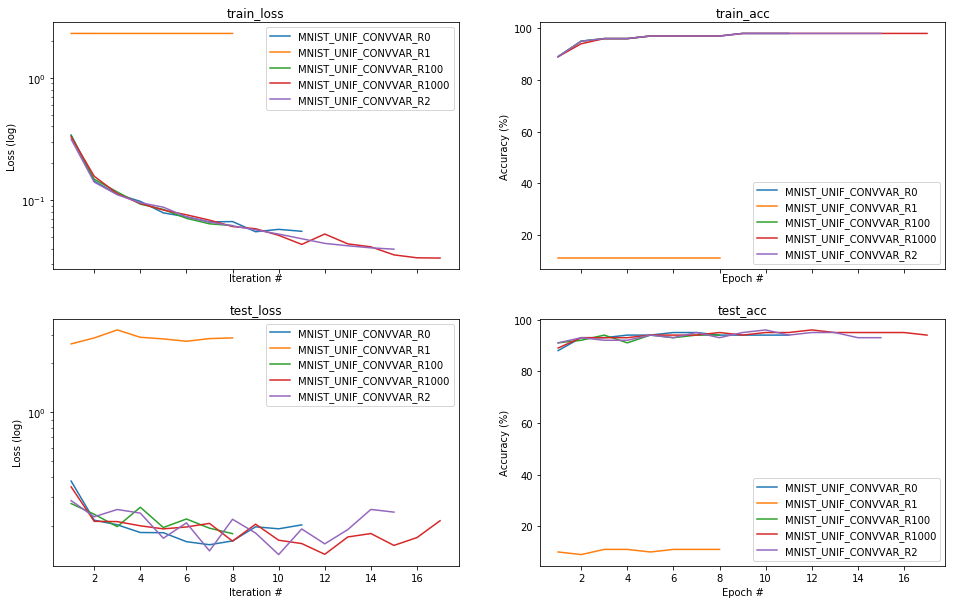

```python
plot_exp_results('exp2*.json')
```

### Results

| R | Best Train Loss | Best Train acc | Best Test loss | best Test acc |
| --- | --- | --- | --- | --- |
| R0 | 0.055659598316441274 | 98 | 0.20186154544353485 | 94 |
| R1 | 2.3012594434498217 | 11 | 2.8725695610046387 | 11 |
| R2 | 0.039756104022439225 | 98 | 0.24201349914073944 | 93 |
| R100 | 0.0619933159688293 | 97 | 0.17833809554576874 | 94 |
| R1000 | 0.03364486032243032 | 98 | 0.2141132950782776 | 94 |

**Experiment 3 - MNIST with discretized Normal Distributions Using a Linear Variance Layer**

```
results/exp3_MNIST_NORM_LINEARVAR_R0.json
results/exp3_MNIST_NORM_LINEARVAR_R1.json
results/exp3_MNIST_NORM_LINEARVAR_R100.json
results/exp3_MNIST_NORM_LINEARVAR_R1000.json
results/exp3_MNIST_NORM_LINEARVAR_R2.json
common config:  {'run_name': 'exp3_MNIST_NORM_LINEARVAR_R2', 'out_dir': './results', 'seed': 1662893862, 'bs_train': 128, 'bs_test': 32, 'batches': 100, 'epochs': 100, 'early_stopping': 5, 'checkpoints': None, 'lr': 0.0015, 'reg': 0.0002, 'pool_every': 0, 'hidden_dims': 0, 'ycn': 'LeNet5FCVariance',…
LeNet5FCVariance(
  (feature_extractor): Sequential(
    (0): Conv2d(1, 20, kernel_size=(5, 5), stride=(1, 1), bias=False)
    (1): BatchNorm2d(20, eps=1e-05, momentum=0.1, affine=False, track_running_stats=True)
    (2): ReLU()
    (3): MaxPool2d(kernel_size=(2, 2), stride=(2, 2), padding=0, dilation=1, ceil_mode=False)
    (4): Conv2d(20, 50, kernel_size=(5, 5), stride=(1, 1), bias=False)
    (5): BatchNorm2d(50, eps=1e-05, momentum=0.1, affine=False, track_running_stats=True)
    (6): ReLU()
    (7): MaxPool2d(kernel_size=(2, 2), stride=(2, 2), padding=0, dilation=1, ceil_mode=False)
  )
  (classifier): Sequential(
    (0): LinearVariance(in_features=800, out_features=500, bias=False, rounding=2)
    (1): BatchNorm1d(500, eps=1e-05, momentum=0.1, affine=False, track_running_stats=True)
    (2): ReLU()
    (3): Linear(in_features=500, out_features=10, bias=True)
  )
)
```

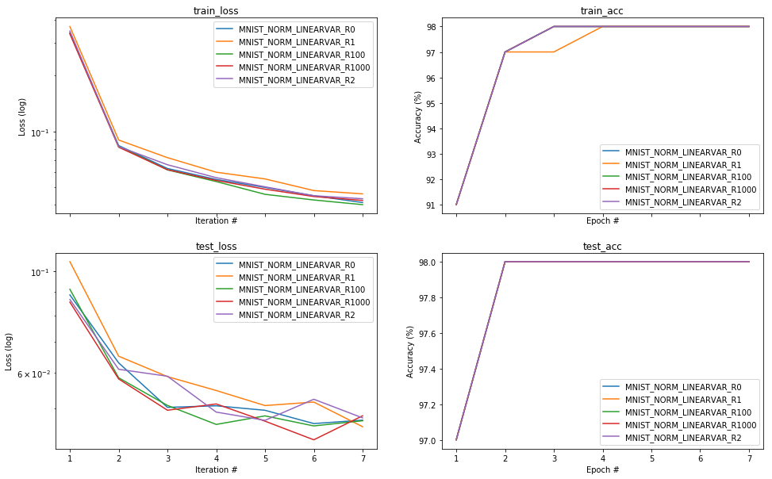

```python
plot_exp_results('exp3*.json')
```

### Results

| R | Best Train Loss | Best Train acc | Best Test loss | best Test acc |
| --- | --- | --- | --- | --- |
| R1 | 0.0458785220782068 | 98 | 0.04565785825252533 | 98 |
| R2 | 0.04316875442806909 | 98 | 0.04773266613483429 | 98 |
| R100 | 0.04010647334563516 | 98 | 0.047050394117832184 | 98 |
| R1000 | 0.04226982781290214 | 98 | 0.048236653208732605 | 98 |

**Experiment 4 - MNIST with discretized Uniform Distributions Using a Linear Variance Layer**

```
results/exp4_MNIST_UNIF_LINEARVAR_R0.json
results/exp4_MNIST_UNIF_LINEARVAR_R1.json
results/exp4_MNIST_UNIF_LINEARVAR_R100.json
results/exp4_MNIST_UNIF_LINEARVAR_R1000.json
results/exp4_MNIST_UNIF_LINEARVAR_R2.json
common config:  {'run_name': 'exp4_MNIST_UNIF_LINEARVAR_R2', 'out_dir': './results', 'seed': 595363926, 'bs_train': 128, 'bs_test': 32, 'batches': 100, 'epochs': 100, 'early_stopping': 5, 'checkpoints': None, 'lr': 0.0015, 'reg': 0.0002, 'pool_every': 0, 'hidden_dims': 0, 'ycn': 'LeNet5FCVarianceUni…
LeNet5FCVarianceUnif(
  (feature_extractor): Sequential(
    (0): Conv2d(1, 20, kernel_size=(5, 5), stride=(1, 1), bias=False)
    (1): BatchNorm2d(20, eps=1e-05, momentum=0.1, affine=False, track_running_stats=True)
    (2): ReLU()
    (3): MaxPool2d(kernel_size=(2, 2), stride=(2, 2), padding=0, dilation=1, ceil_mode=False)
    (4): Conv2d(20, 50, kernel_size=(5, 5), stride=(1, 1), bias=False)
    (5): BatchNorm2d(50, eps=1e-05, momentum=0.1, affine=False, track_running_stats=True)
    (6): ReLU()
    (7): MaxPool2d(kernel_size=(2, 2), stride=(2, 2), padding=0, dilation=1, ceil_mode=False)
  )
  (classifier): Sequential(
    (0): LinearVarianceUnif(in_features=800, out_features=500, bias=False, rounding=2)
    (1): BatchNorm1d(500, eps=1e-05, momentum=0.1, affine=False, track_running_stats=True)
    (2): ReLU()
    (3): Linear(in_features=500, out_features=10, bias=True)
  )
)
```

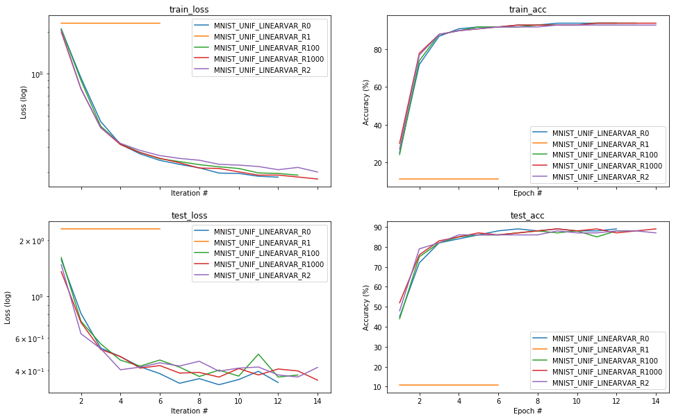

```python
plot_exp_results('exp4*.json')
```

### Results

| R | Best Train Loss | Best Train acc | Best Test loss | best Test acc |
| --- | --- | --- | --- | --- |
| R0 | 0.1831113356532954 | 94 | 0.34522804617881775 | 89 |
| R1 | 2.301286769574131 | 11 | 2.301161289215088 | 11 |
| R2 | 0.19917187814527293 | 93 | 0.41590484976768494 | 87 |
| R100 | 0.18913034130054623 | 94 | 0.3786175549030304 | 88 |
| R1000 | 0.17747989785410703 | 94 | 0.3554050922393799 | 89 |

**Interim Summary - Performance on MNIST**

We notice that using the discrete distributions give performance which is as good as the performance with the continuous distribution. The choice of which base distribution to use and what architecture was a much more significant factor on the results.

**Experiment 5 - CIFAR10 with discretized Normal Distributions Using a Convolutional Variance Layer**

```
results/exp5_CIFAR10_NORM_CONVVAR_R0.json
results/exp5_CIFAR10_NORM_CONVVAR_R1.json
results/exp5_CIFAR10_NORM_CONVVAR_R100.json
results/exp5_CIFAR10_NORM_CONVVAR_R1000.json
results/exp5_CIFAR10_NORM_CONVVAR_R2.json
common config:  {'run_name': 'exp5_CIFAR10_NORM_CONVVAR_R2', 'out_dir': './results', 'seed': 1403408015, 'bs_train': 128, 'bs_test': 32, 'batches': 100, 'epochs': 100, 'early_stopping': 5, 'checkpoints': None, 'lr': 0.0015, 'reg': 0.0002, 'pool_every': 0, 'hidden_dims': 0, 'ycn': 'LeNet5ConvVariance…
Files already downloaded and verified
Files already downloaded and verified
LeNet5ConvVariance(
  (feature_extractor): Sequential(
    (0): ConvVariance(3, 20, kernel_size=(5, 5), stride=1, padding=0, dilation=1, rounding=2, bias=False)
    (1): BatchNorm2d(20, eps=1e-05, momentum=0.1, affine=False, track_running_stats=True)
    (2): ReLU()
    (3): MaxPool2d(kernel_size=(2, 2), stride=(2, 2), padding=0, dilation=1, ceil_mode=False)
    (4): Conv2d(20, 50, kernel_size=(5, 5), stride=(1, 1), bias=False)
    (5): BatchNorm2d(50, eps=1e-05, momentum=0.1, affine=False, track_running_stats=True)
    (6): ReLU()
    (7): MaxPool2d(kernel_size=(2, 2), stride=(2, 2), padding=0, dilation=1, ceil_mode=False)
  )
  (classifier): Sequential(
    (0): Linear(in_features=1250, out_features=500, bias=True)
    (1): BatchNorm1d(500, eps=1e-05, momentum=0.1, affine=False, track_running_stats=True)
    (2): ReLU()
    (3): Linear(in_features=500, out_features=10, bias=True)
  )
)
```

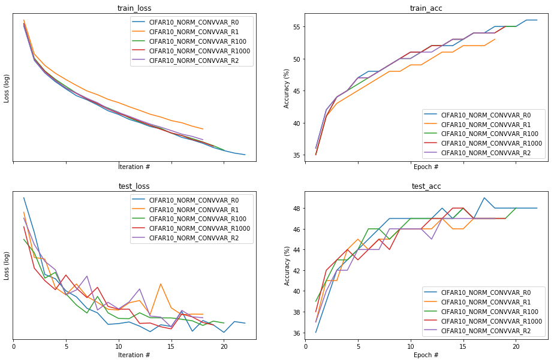

```python
plot_exp_results('exp5*.json')
```

### Results

| R | Best Train Loss | Best Train acc | Best Test loss | best Test acc |
| --- | --- | --- | --- | --- |
| R0 | 1.2380083526491814 | 56 | 1.5054622888565063 | 48 |
| R1 | 1.3315119173215784 | 53 | 1.5235161781311035 | 47 |
| R2 | 1.2916852159573293 | 54 | 1.5165290832519531 | 47 |
| R100 | 1.2542013550353477 | 55 | 1.5057677030563354 | 48 |
| R1000 | 1.2679416730885615 | 55 | 1.5018738508224487 | 47 |

**Experiment 6 - CIFAR10 with discretized Uniform Distributions Using a Convolutional Variance Layer**

```
results/exp6_CIFAR10_UNIF_CONVVAR_R0.json
results/exp6_CIFAR10_UNIF_CONVVAR_R1.json
results/exp6_CIFAR10_UNIF_CONVVAR_R100.json
results/exp6_CIFAR10_UNIF_CONVVAR_R1000.json
results/exp6_CIFAR10_UNIF_CONVVAR_R2.json
common config:  {'run_name': 'exp6_CIFAR10_UNIF_CONVVAR_R2', 'out_dir': './results', 'seed': 448977134, 'bs_train': 128, 'bs_test': 32, 'batches': 100, 'epochs': 100, 'early_stopping': 5, 'checkpoints': None, 'lr': 0.0015, 'reg': 0.0002, 'pool_every': 0, 'hidden_dims': 0, 'ycn': 'LeNet5ConvVarianceU…
Files already downloaded and verified
Files already downloaded and verified
LeNet5ConvVarianceUnif(
  (feature_extractor): Sequential(
    (0): ConvVarianceUnif(3, 20, kernel_size=(5, 5), stride=1, padding=0, dilation=1, bias=False)
    (1): BatchNorm2d(20, eps=1e-05, momentum=0.1, affine=False, track_running_stats=True)
    (2): ReLU()
    (3): MaxPool2d(kernel_size=(2, 2), stride=(2, 2), padding=0, dilation=1, ceil_mode=False)
    (4): Conv2d(20, 50, kernel_size=(5, 5), stride=(1, 1), bias=False)
    (5): BatchNorm2d(50, eps=1e-05, momentum=0.1, affine=False, track_running_stats=True)
    (6): ReLU()
    (7): MaxPool2d(kernel_size=(2, 2), stride=(2, 2), padding=0, dilation=1, ceil_mode=False)
  )
  (classifier): Sequential(
    (0): Linear(in_features=1250, out_features=500, bias=True)
    (1): BatchNorm1d(500, eps=1e-05, momentum=0.1, affine=False, track_running_stats=True)
    (2): ReLU()
    (3): Linear(in_features=500, out_features=10, bias=True)
  )
)
```

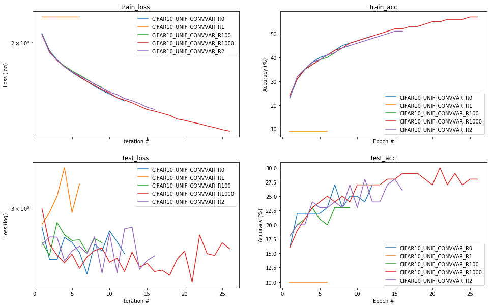

```python
plot_exp_results('exp6*.json')
```

### Results

| R | Best Train Loss | Best Train acc | Best Test loss | best Test acc |
| --- | --- | --- | --- | --- |
| R0 | 1.4375833602207702 | 49 | 2.477161169052124 | 27 |
| R1 | 2.3027473971666885 | 9 | 3.3197453022003174 | 10 |
| R2 | 1.370890420111244 | 51 | 2.4534237384796143 | 26 |
| R100 | 1.5516429584654396 | 45 | 2.593719482421875 | 23 |
| R1000 | 1.2131058614882058 | 57 | 2.5288262367248535 | 28 |

**Experiment 7 - CIFAR10 with discretized Normal Distributions Using a Linear Variance Layer**

```
results/exp7_CIFAR10_NORM_LINEARVAR_R0.json
results/exp7_CIFAR10_NORM_LINEARVAR_R1.json
results/exp7_CIFAR10_NORM_LINEARVAR_R100.json
results/exp7_CIFAR10_NORM_LINEARVAR_R1000.json
results/exp7_CIFAR10_NORM_LINEARVAR_R2.json
common config:  {'run_name': 'exp7_CIFAR10_NORM_LINEARVAR_R2', 'out_dir': './results', 'seed': 1964054517, 'bs_train': 128, 'bs_test': 32, 'batches': 100, 'epochs': 100, 'early_stopping': 5, 'checkpoints': None, 'lr': 0.0015, 'reg': 0.0002, 'pool_every': 0, 'hidden_dims': 0, 'ycn': 'LeNet5FCVariance…
Files already downloaded and verified
Files already downloaded and verified
LeNet5FCVariance(
  (feature_extractor): Sequential(
    (0): Conv2d(3, 20, kernel_size=(5, 5), stride=(1, 1), bias=False)
    (1): BatchNorm2d(20, eps=1e-05, momentum=0.1, affine=False, track_running_stats=True)
    (2): ReLU()
    (3): MaxPool2d(kernel_size=(2, 2), stride=(2, 2), padding=0, dilation=1, ceil_mode=False)
    (4): Conv2d(20, 50, kernel_size=(5, 5), stride=(1, 1), bias=False)
    (5): BatchNorm2d(50, eps=1e-05, momentum=0.1, affine=False, track_running_stats=True)
    (6): ReLU()
    (7): MaxPool2d(kernel_size=(2, 2), stride=(2, 2), padding=0, dilation=1, ceil_mode=False)
  )
  (classifier): Sequential(
    (0): LinearVariance(in_features=1250, out_features=500, bias=False, rounding=2)
    (1): BatchNorm1d(500, eps=1e-05, momentum=0.1, affine=False, track_running_stats=True)
    (2): ReLU()
    (3): Linear(in_features=500, out_features=10, bias=True)
  )
)
```

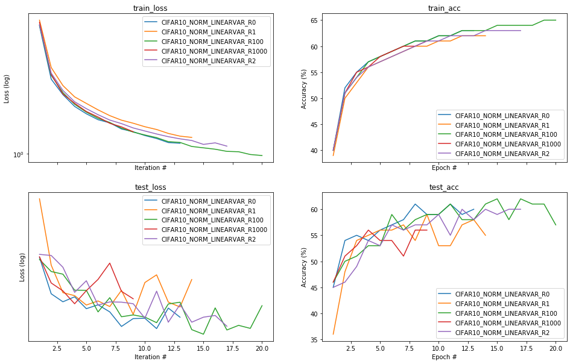

```python
plot_exp_results('exp7*.json')
```

### Results

| R | Best Train Loss | Best Train acc | Best Test loss | best Test acc |
| --- | --- | --- | --- | --- |
| R0 | 1.0394220817119568 | 63 | 1.1604015827178955 | 60 |
| R1 | 1.0617582799528567 | 62 | 1.3532347679138184 | 55 |
| R2 | 1.0285837199072094 | 63 | 1.1184977293014526 | 60 |
| R100 | 0.9941139143446217 | 65 | 1.2163938283920288 | 57 |
| R1000 | 1.0838212456239764 | 61 | 1.2511717081069946 | 56 |

**Experiment 8 - CIFAR10 with discretized Uniform Distributions Using a Linear Variance Layer**

```
results/exp8_CIFAR10_UNIF_LINEARVAR_R0.json
results/exp8_CIFAR10_UNIF_LINEARVAR_R1.json
results/exp8_CIFAR10_UNIF_LINEARVAR_R100.json
results/exp8_CIFAR10_UNIF_LINEARVAR_R1000.json
results/exp8_CIFAR10_UNIF_LINEARVAR_R2.json
common config:  {'run_name': 'exp8_CIFAR10_UNIF_LINEARVAR_R2', 'out_dir': './results', 'seed': 82328646, 'bs_train': 128, 'bs_test': 32, 'batches': 100, 'epochs': 100, 'early_stopping': 5, 'checkpoints': None, 'lr': 0.0015, 'reg': 0.0002, 'pool_every': 0, 'hidden_dims': 0, 'ycn': 'LeNet5FCVarianceUn…
Files already downloaded and verified
Files already downloaded and verified
LeNet5FCVarianceUnif(
  (feature_extractor): Sequential(
    (0): Conv2d(3, 20, kernel_size=(5, 5), stride=(1, 1), bias=False)
    (1): BatchNorm2d(20, eps=1e-05, momentum=0.1, affine=False, track_running_stats=True)
    (2): ReLU()
    (3): MaxPool2d(kernel_size=(2, 2), stride=(2, 2), padding=0, dilation=1, ceil_mode=False)
    (4): Conv2d(20, 50, kernel_size=(5, 5), stride=(1, 1), bias=False)
    (5): BatchNorm2d(50, eps=1e-05, momentum=0.1, affine=False, track_running_stats=True)
    (6): ReLU()
    (7): MaxPool2d(kernel_size=(2, 2), stride=(2, 2), padding=0, dilation=1, ceil_mode=False)
  )
  (classifier): Sequential(
    (0): LinearVarianceUnif(in_features=1250, out_features=500, bias=False, rounding=2)
    (1): BatchNorm1d(500, eps=1e-05, momentum=0.1, affine=False, track_running_stats=True)
    (2): ReLU()
    (3): Linear(in_features=500, out_features=10, bias=True)
  )
)
```

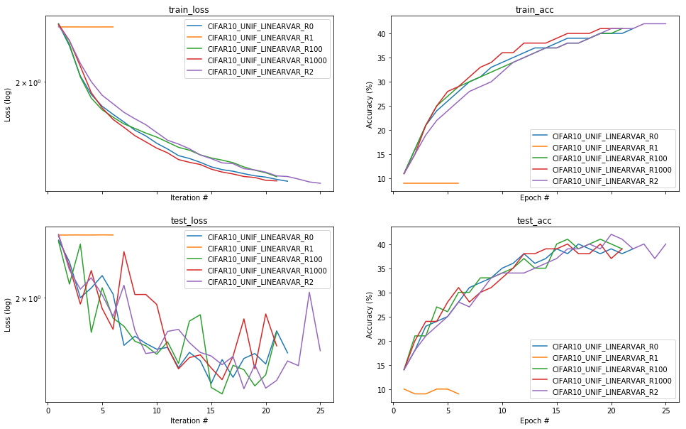

```python
plot_exp_results('exp8*.json')
```

### Results

| R | Best Train Loss | Best Train acc | Best Test loss | best Test acc |
| --- | --- | --- | --- | --- |
| R0 | 1.548347472229882 | 41 | 1.764874815940857 | 39 |
| R1 | 2.3027838075252447 | 9 | 2.3027844429016113 | 9 |
| R2 | 1.5401615361728327 | 42 | 1.7734571695327759 | 40 |
| R100 | 1.5665705423525838 | 41 | 1.8489822149276733 | 39 |
| R1000 | 1.5496253994724634 | 41 | 1.793283462524414 | 39 |

**Thoughts and Analysis**

1. Some of the graphs show practically no difference between the different distributions.  
   This is particularly surprising in the layers where R=1 is able to train (Normally distributed ones). It makes us think that the fine tuned values which can be received are of little importance to the layer. In some experiments, we can even see R2 outperforming the continuous distribution. Perhaps an explanation could be that less possible values give us more generality.
2. R1 is not training with uniform distribution.  
   As we stated in the introduction, the weights of this distribution are attained from rounding $U(-x,x)$. If $x<1/2$, which could be the case here, we will find that the distribution emits a constant 0. In order to get a varied number of values, the variance would need to be quite high. This isn't the case with a normal distribution, where there is a countably infinite number of values which are attained with some probability.
3. Graphs at test time are a lot less consistent than training time.  
   This can be accredited to the batch sizes used: 128 for training and 32 for testing. As this is a stochastic network, consistent behavior is achieved with large numbers.

To summarize, our experiment shows that discrete distributions can be used with variance layers. We showed that some of them perform just as well or almost just as well which may be sufficient for the user's purposes. This opens the gate to using these networks with low precision hardware, which would hold a discrete distribution of some kind.

#### github Repository

Implementation along with training and tests results and additional utils can be found at https://github.com/shayfroid/cs236605FinalProject.